# R Notebook

This code was written by II for the manuscript: https://doi.org/10.1093/icesjms/fsae129 This code is preceded by “satellite.Rmd” and followed by “Analysis 2 plots.Rmd”

# Objective of code:

- checks for correlation among ocean variables
- runs a GAM model with ocean covariates
- evaluates model fit

86 total 25 by 25 km cells that have all oceanographic data and ocean covariates (df: acoustics_ctd)

# Background:

Interested in which oceanographic variables may be influencing center of mass depth (vertical position) of mesopelagic fishes. Using a combination of CTD and satellite (light) data, construct a generalized additive model (GAM) to determine whether the variables influenced center of mass depth.

# gratia

install.packages(“gratia”,repos = c(“https://gavinsimpson.r-universe.dev”,“https://cloud.r-project.org”))

# load packages

```r
# update any installed R packages
#update.packages(ask = TRUE, checkBuilt = TRUE)
library(mgcv) # GAM function
library(gratia) # gam plotting by Gavin Simpson (course instructor) - need to reload for most recent version
library(tidyverse)
```

# Look at the distribution of our response variable: CM Center of Mass (m)

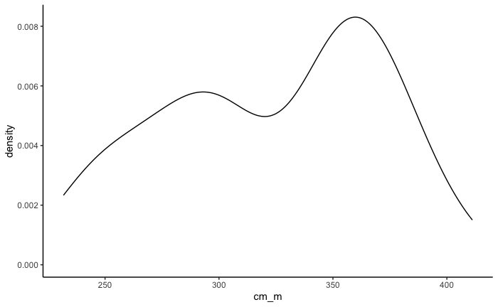

```r
acoustics_ctd |>
  ggplot()+
  geom_density(aes(x=cm_m))+
  #geom_histogram(aes(x=CM), color="black", fill="white")+
  #facet_wrap(~Year)+
  theme_classic()
```

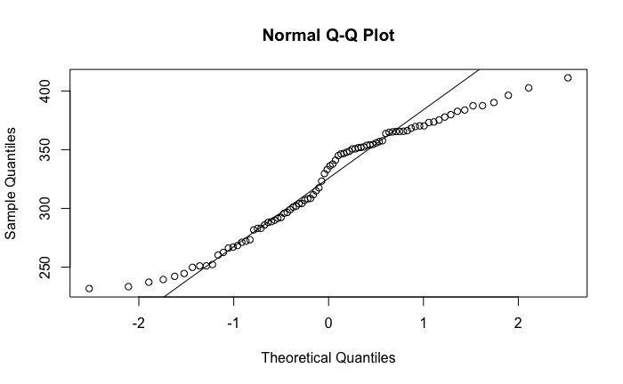

```r
  # could also create a q-q plot
qqnorm(acoustics_ctd$cm_m)
qqline(acoustics_ctd$cm_m)
```

# Pairplot

To evaluate linear correlation within our data

# pairs plot via ggplot

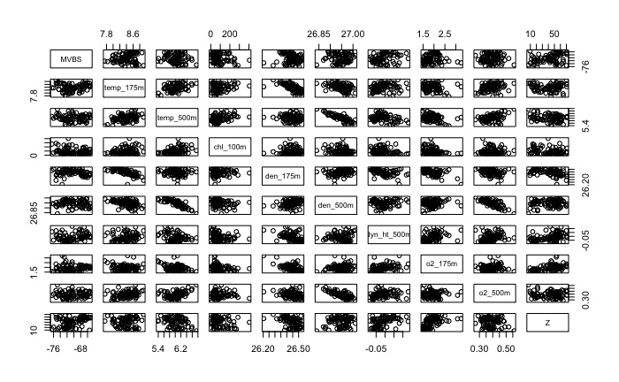

```r
ocean_corr= acoustics_ctd |>
  dplyr::select( MVBS, temp_175m, temp_500m, chl_100m, den_175m, den_500m, dyn_ht_500m, o2_175m, o2_500m, Z) #note that DEPTH_o2_05 is missing data points so might be causing errors

pairs(ocean_corr) # base R, hard ot read
```

```r
# Install package
library(GGally)

ggpairs(ocean_corr, upper = list(continuous=wrap("cor", size=2)))+
  theme(strip.text.x = element_text(size = 5),
           strip.text.y = element_text(size = 5),
        axis.text = element_text(size=5)) #change label size
```

[output not shown]

[output cut: 45 more lines]

[output not shown]

[output not shown]

[output cut: 45 more lines]

[output not shown]

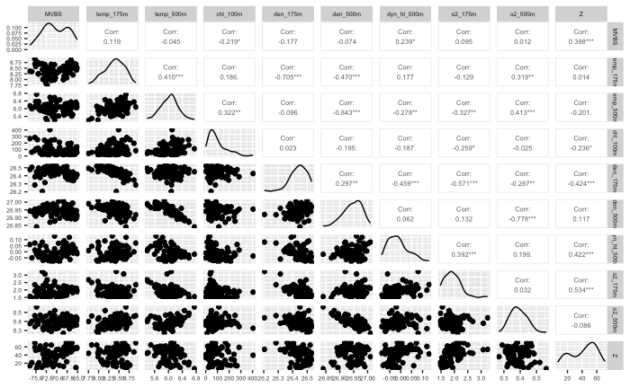

```r
ggsave("./plots/analysis 2/paris.pdf")
```

Remove those terms with correlation coefficients >0.7 based on Dormann

This leaves: MVBS, temp_175m, temp_500m, chl_100m, dyn_ht_500m, o2_175m, o2_500m, Z (we removed density at 175 m and denstiy at 500 m)

# FULL MODEL– fit a GAM – prior to concurvity evaluation (concurvity describes non linear correlation)

Fit our full model with all of the covariates that passed our colinear examination while noting that we will need to additionally remove covariates that approximate eachother (concurvity)

```r
summary.gam(m_full)
```

```
Family: gaussian
Link function: identity

Formula:
cm_m ~ s(temp_175m) + s(temp_500m) + s(o2_175m) + s(o2_500m) +
    s(chl_100m) + s(dyn_ht_500m) + s(MVBS) + s(Z)

Parametric coefficients:
            Estimate Std. Error t value Pr(>|t|)
(Intercept)  323.367      2.284   141.5   <2e-16 ***
---
Signif. codes:  0 ‘***’ 0.001 ‘**’ 0.01 ‘*’ 0.05 ‘.’ 0.1 ‘ ’ 1

Approximate significance of smooth terms:
                     edf Ref.df     F  p-value
s(temp_175m)   0.1150310      9 0.014   0.2746
s(temp_500m)   1.3412709      9 0.497   0.0265 *
s(o2_175m)     1.1421112      9 0.319   0.0712 .
s(o2_500m)     0.0014996      9 0.000   0.3213
s(chl_100m)    0.0001606      9 0.000   0.6933
s(dyn_ht_500m) 3.0128590      9 5.085  < 2e-16 ***
s(MVBS)        1.9611543      9 1.899 9.91e-05 ***
s(Z)           0.9804853      9 5.379  < 2e-16 ***
---
Signif. codes:  0 ‘***’ 0.001 ‘**’ 0.01 ‘*’ 0.05 ‘.’ 0.1 ‘ ’ 1

R-sq.(adj) =  0.803   Deviance explained = 82.3%
-REML = 392.92  Scale est. = 448.83    n = 86
```

A note on covariate selection:

Based on the pairs plot above, I removed variables that had a correlation coefficient of 0.7 or greater (although some were close to this). Will now check all of these correlations with concurvity feature of GAM output

# View output of model

format(2e-16,scientific=FALSE) # to see p-values in non scientific notation Customizing plots with gratia https://gavinsimpson.github.io/gratia/articles/custom-plotting.html

```r
# MODEL fit: amount explained, significant covariates
summary(m_full)  # model summary
```

```
Family: gaussian
Link function: identity

Formula:
cm_m ~ s(temp_175m) + s(temp_500m) + s(o2_175m) + s(o2_500m) +
    s(chl_100m) + s(dyn_ht_500m) + s(MVBS) + s(Z)

Parametric coefficients:
            Estimate Std. Error t value Pr(>|t|)
(Intercept)  323.367      2.284   141.5   <2e-16 ***
---
Signif. codes:  0 ‘***’ 0.001 ‘**’ 0.01 ‘*’ 0.05 ‘.’ 0.1 ‘ ’ 1

Approximate significance of smooth terms:
                     edf Ref.df     F  p-value
s(temp_175m)   0.1150310      9 0.014   0.2746
s(temp_500m)   1.3412709      9 0.497   0.0265 *
s(o2_175m)     1.1421112      9 0.319   0.0712 .
s(o2_500m)     0.0014996      9 0.000   0.3213
s(chl_100m)    0.0001606      9 0.000   0.6933
s(dyn_ht_500m) 3.0128590      9 5.085  < 2e-16 ***
s(MVBS)        1.9611543      9 1.899 9.91e-05 ***
s(Z)           0.9804853      9 5.379  < 2e-16 ***
---
Signif. codes:  0 ‘***’ 0.001 ‘**’ 0.01 ‘*’ 0.05 ‘.’ 0.1 ‘ ’ 1

R-sq.(adj) =  0.803   Deviance explained = 82.3%
-REML = 392.92  Scale est. = 448.83    n = 86
```

# PLOT relationship between covariates and center of mass depth :: DRAW

For reference: mgcv::plot.gam(m_full) #plot with mgcv package

[figure not shown]

```r
# PLOT: relationship of covariate to cm depth
gratia::draw(m_full)& # plot with gratia
ggthemes::theme_few() #note use of & in plot to apply theme options to all plots instead of just one
```

# Plot with {mgcv}

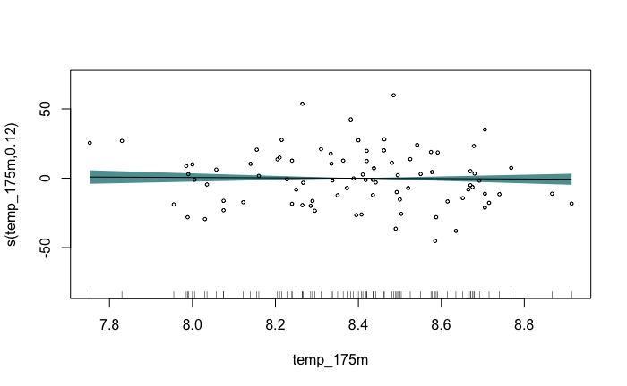

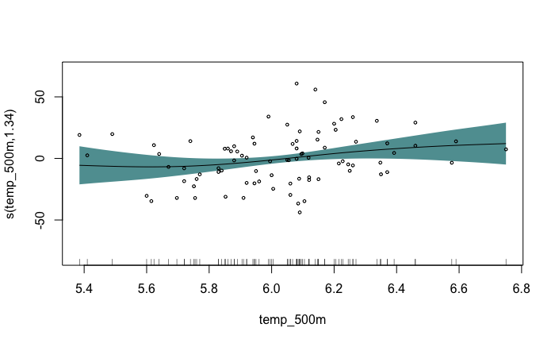

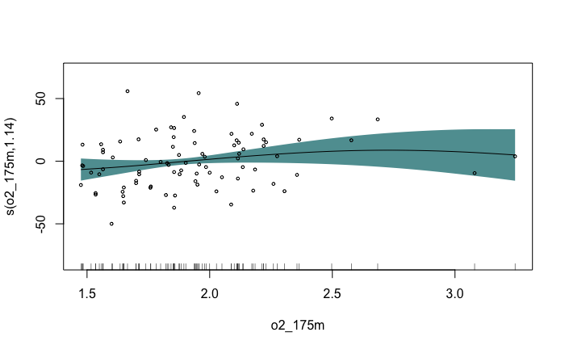

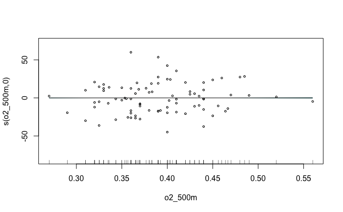

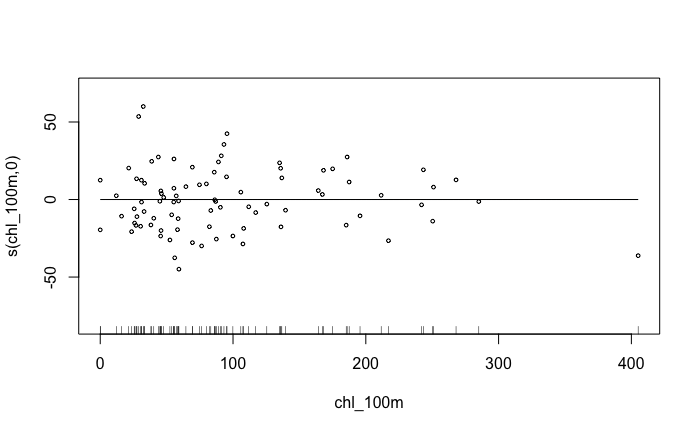

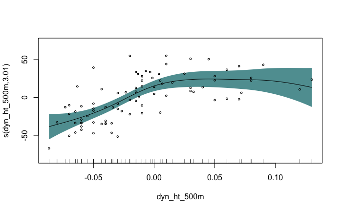

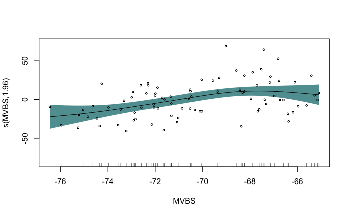

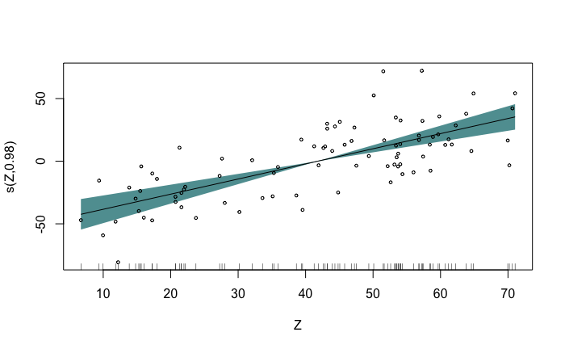

```r
plot(m_full, rug = TRUE, residuals = TRUE, se=TRUE, shade=TRUE, shade.col="cadetblue",
     pch = 1, cex = 0.5) #this includes points for residuals
```

# Examine model fit via {gratia}

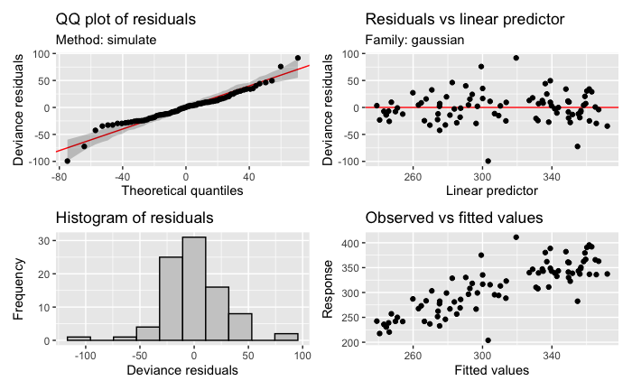

```r
appraise(m_full, method = "simulate") # look at plot diagnostics
```

```r
# the fit actually is pretty good approximately Gaussian, good fit except for at the tails, no real structure not bad
```

# Further examine correlation (non-linear) amongst variables using the concurvity function on our output

first have to rule out any additional correlation among covariates

```r
# overall concurvity
gratia::concrvity(m_full, pairwise = FALSE) # if less than 0.8 all terms ok
```

| .type | .term | .concurvity |
| --- | --- | --- |
| worst | para | 2.599932e-19 |
| worst | s(temp_175m) | 9.762066e-01 |
| worst | s(temp_500m) | 9.982686e-01 |
| worst | s(o2_175m) | 9.987161e-01 |
| worst | s(o2_500m) | 9.948303e-01 |
| worst | s(chl_100m) | 9.707966e-01 |
| worst | s(dyn_ht_500m) | 9.569381e-01 |
| worst | s(MVBS) | 9.656765e-01 |
| worst | s(Z) | 9.769549e-01 |
| observed | para | 2.599932e-19 |

[output cut: 17 more lines]

```r
# if greater than 0.8, run pairwise comparisons

conc <- concrvity(m_full, pairwise = TRUE)
conc
```

| .type | .term | .with | .concurvity |
| --- | --- | --- | --- |
| worst | para | para | 1.000000e+00 |
| worst | para | s(temp_175m) | 2.359441e-21 |
| worst | para | s(temp_500m) | 2.593819e-20 |
| worst | para | s(o2_175m) | 9.711727e-25 |
| worst | para | s(o2_500m) | 2.425856e-25 |
| worst | para | s(chl_100m) | 7.253639e-26 |
| worst | para | s(dyn_ht_500m) | 6.245703e-22 |
| worst | para | s(MVBS) | 1.256076e-25 |
| worst | para | s(Z) | 1.312461e-26 |
| worst | s(temp_175m) | para | 2.359509e-21 |

[output cut: 233 more lines]

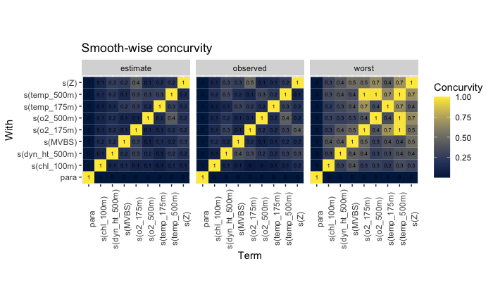

```r
draw(conc)+
  geom_text(aes(label=round(.concurvity, 1)), size=2)+ #add actual values ot plot sweet none above 0.5
  theme(axis.text.x = element_text(angle=90))

ggsave("./plots/analysis 2/concurvity.pdf")
```

# Helpful references

https://gavinsimpson.github.io/gratia/reference/model_concurvity.html https://stats.stackexchange.com/questions/580791/interpretation-of-estimate-concurvity-vs-worst-concurvity-in-gams for interpretation NOAM ROSS: https://noamross.github.io/gams-in-r-course/chapter2

NROSS: “in general, we avoid putting multiple collinear variables into the same model” “with GAMS we have an additional potential pitfall. Even if two variables aren’t collinear, they may have concurvity, that is, one may be a smooth curve of another” If we use both variables as predictors in a model, we get smooths with wild confidence intervals

Based on this advice, we then have to additionally remove covariates: temperature at 500m

#More on concurvity

```r
concurvity(m_full, full = TRUE) #overall - if any values high, run full=FALSE for pairwise comparisons
concur=concurvity(m_full, full = FALSE) # pairwise concurvities
concur$worst #look at output for "worst" value
# convert format
format(concur$worst, scientific = FALSE) #convert from scientific notation but harder to read look for values greater than 0.5
```

The following is the final list of covariates: between oxygen and temperature, oxygen makes more sense because there is some evidence that biologically limiting

# FINAL MODEL -GAM

Redo the procedure from above but with set of non-correlated covariates (now all non correlated (checked both colinarity and concurvity))

```r
# modified GAM model: use this one after convo with Jerome!!!
m_final <- mgcv::gam(cm_m ~
                s(temp_175m) +  # temperature at 175m depth
                s(o2_175m)+ # oxygen at 175 m
                s(o2_500m)+ # oxygen at 500 m
                s(chl_100m) + # integrated chl
                s(dyn_ht_500m) + # dynamic height anomaly
                s(MVBS)+ #overall backscatter/biomass
                s(Z), #depth at which light is 1% of surface note could also make this a linear term with Z instead of s(Z), same output 71.4%
    data = acoustics_ctd, method = "REML", family = gaussian(), select = TRUE)

# note all bs="tp" basis functions are thin-plate splines by default and appropriate for our analysis

summary(m_final)
```

```
Family: gaussian
Link function: identity

Formula:
cm_m ~ s(temp_175m) + s(o2_175m) + s(o2_500m) + s(chl_100m) +
    s(dyn_ht_500m) + s(MVBS) + s(Z)

Parametric coefficients:
            Estimate Std. Error t value Pr(>|t|)
(Intercept)  323.367      2.327     139   <2e-16 ***
---
Signif. codes:  0 ‘***’ 0.001 ‘**’ 0.01 ‘*’ 0.05 ‘.’ 0.1 ‘ ’ 1

Approximate significance of smooth terms:
                     edf Ref.df     F  p-value
s(temp_175m)   0.0001720      9 0.000 0.471566
s(o2_175m)     0.8546662      9 0.181 0.138207
s(o2_500m)     0.6414550      9 0.198 0.093325 .
s(chl_100m)    0.0001985      9 0.000 0.579721
s(dyn_ht_500m) 3.0972126      9 4.476  < 2e-16 ***
s(MVBS)        1.8849767      9 1.695 0.000219 ***
s(Z)           1.0651002      9 5.942  < 2e-16 ***
---
Signif. codes:  0 ‘***’ 0.001 ‘**’ 0.01 ‘*’ 0.05 ‘.’ 0.1 ‘ ’ 1

R-sq.(adj) =  0.796   Deviance explained = 81.4%
-REML = 393.54  Scale est. = 465.56    n = 86
```

Model explained ~81% of variability in center of mass depth (m)

```r
conc <- concrvity(m_final, pairwise = TRUE)
conc
```

| .type | .term | .with | .concurvity |
| --- | --- | --- | --- |
| worst | para | para | 1.000000e+00 |
| worst | para | s(temp_175m) | 2.359441e-21 |
| worst | para | s(o2_175m) | 9.711727e-25 |
| worst | para | s(o2_500m) | 2.425856e-25 |
| worst | para | s(chl_100m) | 7.253639e-26 |
| worst | para | s(dyn_ht_500m) | 6.245703e-22 |
| worst | para | s(MVBS) | 1.256076e-25 |
| worst | para | s(Z) | 1.312461e-26 |
| worst | s(temp_175m) | para | 2.359509e-21 |
| worst | s(temp_175m) | s(temp_175m) | 1.000000e+00 |

[output cut: 182 more lines]

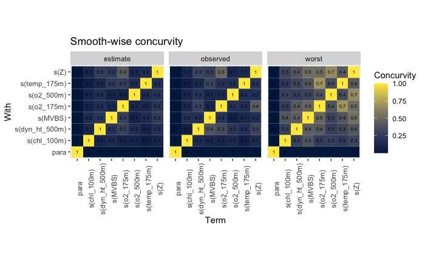

```r
draw(conc)+
  geom_text(aes(label=round(.concurvity, 1)), size=2)+ #add actual values ot plot sweet none above 0.5
  theme(axis.text.x = element_text(angle=90))
```

# Summary of final model

```r
summary(m_final)
```

```
Family: gaussian
Link function: identity

Formula:
cm_m ~ s(temp_175m) + s(o2_175m) + s(o2_500m) + s(chl_100m) +
    s(dyn_ht_500m) + s(MVBS) + s(Z)

Parametric coefficients:
            Estimate Std. Error t value Pr(>|t|)
(Intercept)  323.367      2.327     139   <2e-16 ***
---
Signif. codes:  0 ‘***’ 0.001 ‘**’ 0.01 ‘*’ 0.05 ‘.’ 0.1 ‘ ’ 1

Approximate significance of smooth terms:
                     edf Ref.df     F  p-value
s(temp_175m)   0.0001720      9 0.000 0.471566
s(o2_175m)     0.8546662      9 0.181 0.138207
s(o2_500m)     0.6414550      9 0.198 0.093325 .
s(chl_100m)    0.0001985      9 0.000 0.579721
s(dyn_ht_500m) 3.0972126      9 4.476  < 2e-16 ***
s(MVBS)        1.8849767      9 1.695 0.000219 ***
s(Z)           1.0651002      9 5.942  < 2e-16 ***
---
Signif. codes:  0 ‘***’ 0.001 ‘**’ 0.01 ‘*’ 0.05 ‘.’ 0.1 ‘ ’ 1

R-sq.(adj) =  0.796   Deviance explained = 81.4%
-REML = 393.54  Scale est. = 465.56    n = 86
```

```r
mgcv::summary.gam(m_final) #same same just via {mgcv}
```

```
Family: gaussian
Link function: identity

Formula:
cm_m ~ s(temp_175m) + s(o2_175m) + s(o2_500m) + s(chl_100m) +
    s(dyn_ht_500m) + s(MVBS) + s(Z)

Parametric coefficients:
            Estimate Std. Error t value Pr(>|t|)
(Intercept)  323.367      2.327     139   <2e-16 ***
---
Signif. codes:  0 ‘***’ 0.001 ‘**’ 0.01 ‘*’ 0.05 ‘.’ 0.1 ‘ ’ 1

Approximate significance of smooth terms:
                     edf Ref.df     F  p-value
s(temp_175m)   0.0001720      9 0.000 0.471566
s(o2_175m)     0.8546662      9 0.181 0.138207
s(o2_500m)     0.6414550      9 0.198 0.093325 .
s(chl_100m)    0.0001985      9 0.000 0.579721
s(dyn_ht_500m) 3.0972126      9 4.476  < 2e-16 ***
s(MVBS)        1.8849767      9 1.695 0.000219 ***
s(Z)           1.0651002      9 5.942  < 2e-16 ***
---
Signif. codes:  0 ‘***’ 0.001 ‘**’ 0.01 ‘*’ 0.05 ‘.’ 0.1 ‘ ’ 1

R-sq.(adj) =  0.796   Deviance explained = 81.4%
-REML = 393.54  Scale est. = 465.56    n = 86
```